# Tooth Growth Guinea Pig

Luiz Bergo

06/11/2019

## Tooth Growth Guinea Pig

This document present analisys on dataset “ToothGrowth” available at R default packages.

This is required as part of Statistical Inference course from Johns Hopkins University powered by Coursera.

The dataset is composed by 60 records of experiments on doses of *Vitamin C* administrated on a population of Guinea Pigs. The vitamin was introducted in pig´s diets in two forms as *Orange Juice* or *Ascorbic Acid* and the results on pig´s teeth group was recorded.

A summary of experiment table is shown:

```r
data(ToothGrowth)
dt <- ToothGrowth
str(dt)
```

```
## 'data.frame':    60 obs. of  3 variables:
##  $ len : num  4.2 11.5 7.3 5.8 6.4 10 11.2 11.2 5.2 7 ...
##  $ supp: Factor w/ 2 levels "OJ","VC": 2 2 2 2 2 2 2 2 2 2 ...
##  $ dose: num  0.5 0.5 0.5 0.5 0.5 0.5 0.5 0.5 0.5 0.5 ...
```

Brief description of each column:

## Data investigation

After observing the data a main question is raised:

- Wich form of *Vitamin C* promote greatest teeth growth?

Aiming answer this question a simple box plot is presented.

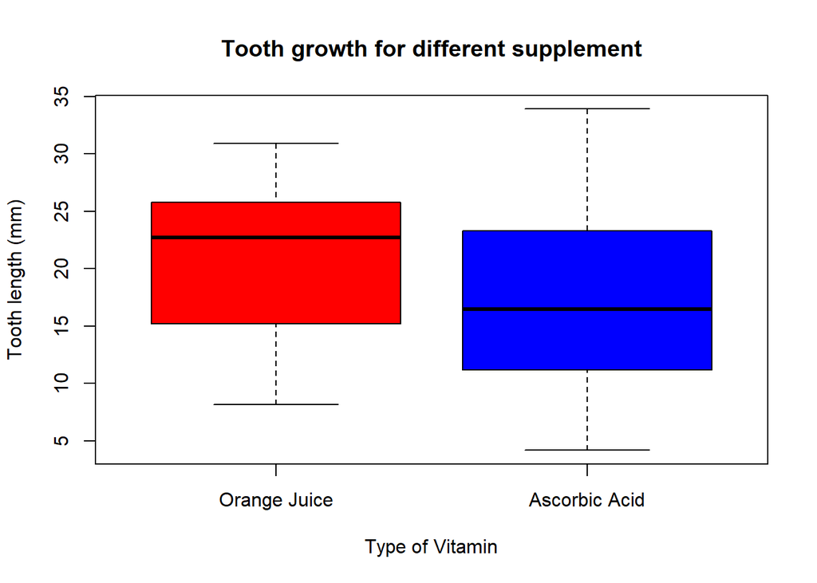

Based on this graphic it is possible to observe that teeth wich pigs were fed with orange juice are bigger than that fed with scorbic acid.

Testing the confidence interval:

$H_{0}: \mu_{OC} = \mu_{VC} \\ H_{a}: \mu_{OC} \ne \mu_{VC}$

Since it is not given any information about teeth grwoth population, a *t test* interval was evaluated considering both, equal and unequal variance between the two groups.

Critical value for a two sided teste with 95% confidence and 58 degrees of freedom:

```
## [1] 2.001717
```

```
##
##  Welch Two Sample t-test
##
## data:  OJ_dt$len and VC_dt$len
## t = 1.9153, df = 55.309, p-value = 0.06063
## alternative hypothesis: true difference in means is not equal to 0
## 95 percent confidence interval:
##  -0.1710156  7.5710156
## sample estimates:
## mean of x mean of y
##  20.66333  16.96333
```

```
##
##  Two Sample t-test
##
## data:  OJ_dt$len and VC_dt$len
## t = 1.9153, df = 58, p-value = 0.06039
## alternative hypothesis: true difference in means is not equal to 0
## 95 percent confidence interval:
##  -0.1670064  7.5670064
## sample estimates:
## mean of x mean of y
##  20.66333  16.96333
```

The *alternative hyphotesis is reject* since in both cases the the confidence intervals include 0 and the observed t-value is inferior to the critical t-value.

Although due to the narrow interval in the lower limit, it´s interesting evaluate the impact of doses in teeth growth.

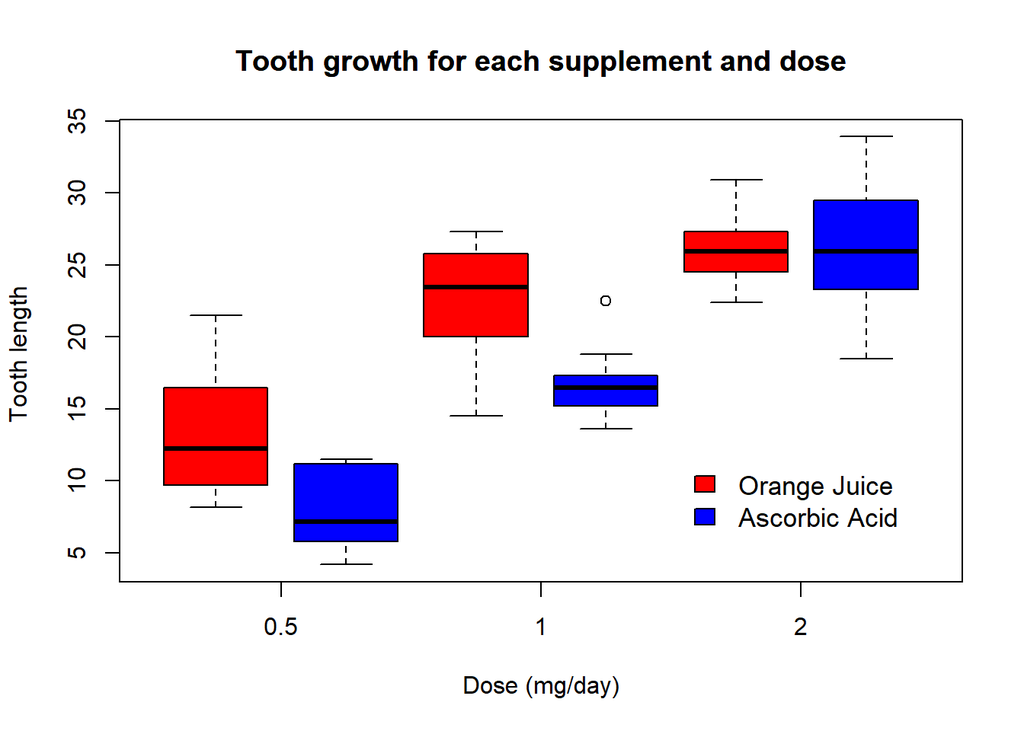

By this graphic it is possible to see that the impact on growth are quite diferente for 0.5 and 1.0 mg/day. To reinforce this hypothesis tests comparing *Dose* and *Supp* for each interval are proposed.

Critical t-value for each dose are:

t-critical for dose of 0.5 mg/day with 95% of significance:

```
## [1] 2.446912
```

t-critical for dose of 1.0 mg/day with 95% of significance:

```
## [1] 2.446912
```

t-critical for dose of 2.0 mg/day with 95% of significance:

```
## [1] 2.446912
```

*Testing the confidence interval for 0.5 mg/day:*

$H_{0}: \mu_{OC,dose=0.5} = \mu_{VC,dose=0.5} \\ H_{a}: \mu_{OC,dose=0.5} \ne \mu_{VC,dose=0.5}$

```
##
##  Welch Two Sample t-test
##
## data:  OJ_dt05$len and VC_dt05$len
## t = 3.1697, df = 14.969, p-value = 0.006359
## alternative hypothesis: true difference in means is not equal to 0
## 95 percent confidence interval:
##  1.719057 8.780943
## sample estimates:
## mean of x mean of y
##     13.23      7.98
```

This result confirm the *sucess to reject the null hypothesis* for a dose of 0.5 mg/day.

*Testing the confidence interval for 1.0 mg/day:*

$H_{0}: \mu_{OC,dose=1.0} = \mu_{VC,dose=1.0} \\ H_{a}: \mu_{OC,dose=1.0} \ne \mu_{VC,dose=1.0}$

```
##
##  Welch Two Sample t-test
##
## data:  OJ_dt10$len and VC_dt10$len
## t = 4.0328, df = 15.358, p-value = 0.001038
## alternative hypothesis: true difference in means is not equal to 0
## 95 percent confidence interval:
##  2.802148 9.057852
## sample estimates:
## mean of x mean of y
##     22.70     16.77
```

This result confirm the *sucess to reject the null hypothesis* for a dose of 1.0 mg/day.

*Testing the confidence interval for 2.0 mg/day:*

$H_{0}: \mu_{OC,dose=2.0} = \mu_{VC,dose=2.0} \\ H_{a}: \mu_{OC,dose=2.0} \ne \mu_{VC,dose=2.0}$

```
##
##  Welch Two Sample t-test
##
## data:  OJ_dt20$len and VC_dt20$len
## t = -0.046136, df = 14.04, p-value = 0.9639
## alternative hypothesis: true difference in means is not equal to 0
## 95 percent confidence interval:
##  -3.79807  3.63807
## sample estimates:
## mean of x mean of y
##     26.06     26.14
```

This result confirm the *fail to reject the null hypothesis* for a dose of 2.0 mg/day.